# Agile inception

Metodologias

En el siguiente artículo te cuento sobre un conjunto de actividades que te permiten reducir la incertidumbre y alinear a todas las personas de un equipo de producto para que puedan tener objetivos comunes.

Romina Mendez https://r0mymendez.github.io/romymendezblog/  
07-17-2022

[figure not shown]

## ¿Que es agile inception?

Se denomina **“agile inception”** a un conjunto de actividades que permite alinear a todas las personas de un equipo de producto para que se puedan tener objetivos comunes.

Este concepto fue introducido por Jonathan Rasmusson en el libro **“The Agile Samurai”** y el conjunto de dinámicas permiten reducir la incertidumbre y los riesgos que pueden existir en un proyecto. Las aplicación de estas técnicas permiten poner objetivos comunes, mejorar la comunicación y eliminar miedos que pueden existir en los integrantes del equipo

Hay que tener en cuenta que no es necesario realizar todas las dinámicas, sino llevar a cabo las necesarias que permitan reducir la incertidumbre que puede existir en el proyecto.

Muchas veces se piensa que la incertidumbre es al inicio del proyecto, pero como se puede visualizar en la siguiente imagen del libro “The Agile Samurai” durante varias etapas del proyecto pueden aparecer los cambios y esto significa que se requieran dinámicas que permitan que el equipo puedan llegar a tener objetivos comunes y lograr acuerdos.

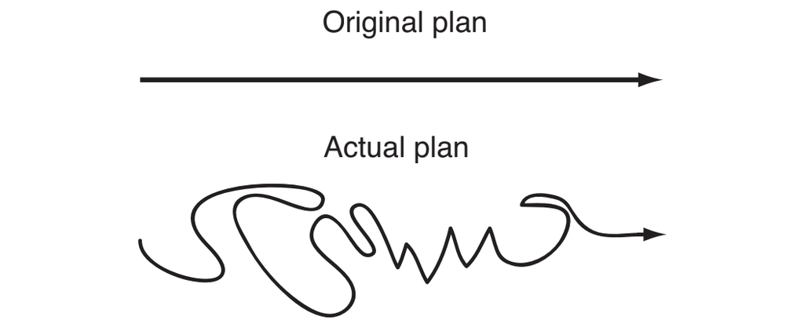

Source image: The agile samurai

## Dinámicas

Como comentamos anteriormente **“agile inception”** tiene un conjunto de 10 dinámicas que permiten disminuir la incertidumbre, mitigar riesgos y generar objetivos comunes en el equipo de desarrollo de producto.

## ¿Porque implementar agile inception?

Al inicio de un proyecto es necesario tomar decisiones en la incertidumbre y para poder realizarlo es necesario:

- ✏️ Definir y comunicar objetivos, visión y contexto del proyecto del equipo.
- ✏️ Divulgar a las partes interesadas la información que necesitan para ayudar a tomar decisiones de cómo proceder en el proyecto.

Estas tareas son necesarias realizarlas de forma ordenada y lograr que todos los integrantes estén de acuerdo con el propósito del proyecto, como se va ejecutar y cuales son los resultados esperados.

## ¿ Cuáles son los beneficios de Agile inception?

- 📌 Unificar la visión y definir el alcance
- 📌 Poner de acuerdo a todos los interesados (stakeholders) en la visión conjunta del proyecto
- 📌 Reducir la incertidumbre
- 📌 Entender cuáles son los riesgos existen que puedan poner en peligro el proyecto.

A continuación se van a detallar cuál es el objetivo de las 10 dinámicas y como llevar a cabo las mismas.

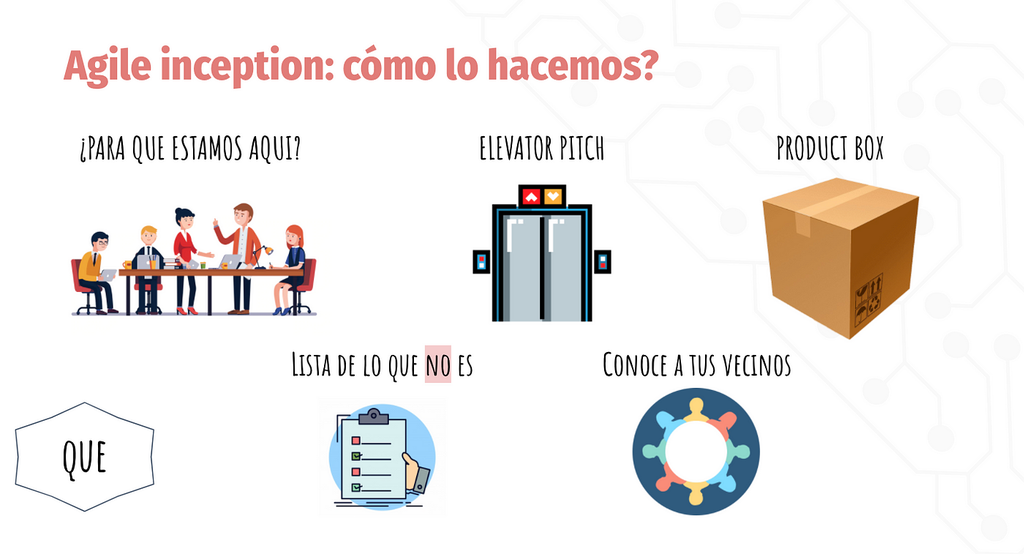

### 1. Para que estamos aquí

Esta actividad tiene como objetivo realizar un recordatorio rápido de por qué estamos aquí, quiénes son nuestros clientes, y por qué decidimos hacer este proyecto.

Una técnica que podemos utilizar es “el círculo dorado de Simon Sinek” que permite conocer que objetivos tiene y cómo hacerlo.

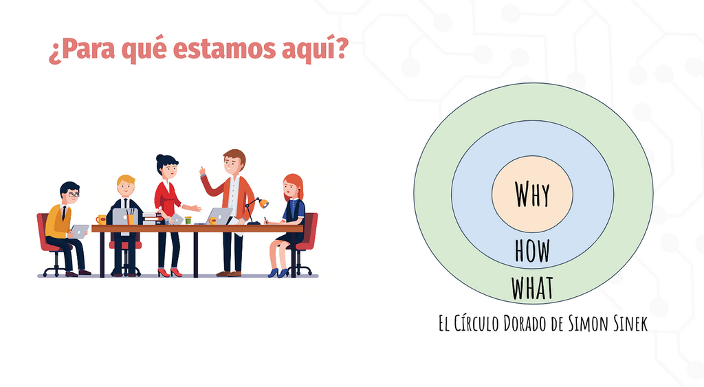

Estas preguntas a realizar son:

1. ✏️ ¿Por qué? Son los motivos o el propósito por el que estamos realizando este proyecto.
2. ✏️ ¿Cómo? Es el proceso o los procesos que son necesarios tener para poder realizar el propósito del proyecto.
3. ✏️ ¿Qué? Es el resultado que queremos generar, puede ser el producto o el servicio a desarrollar.

### 2. Elevator Pitch

Esta técnica permite poder conseguir el interés de un inversor para un proyecto, para lo cual es necesario poder contar sobre el objetivo del mismo en aproximadamente⌛ 30 segundos.

La técnica se asimila a un viaje en un ascensor que llega al último piso de un edificio demorando aproximadamente 30 segundos.

En el siguiente video realizado por [eduCaixa](https://educaixa.org/es/home) puedes ver una representación de que hay que tener en cuenta para realizar un elevator pitch,

[video not shown]

#### Elementos:

| Elementos | Preguntas |
| --- | --- |
| Necesidad | ¿Qué problemática resuelves? |
| Solución | ¿Cómo lo resuelves? Breve descripción. |
| Mercado | ¿Cuál es el mercado al que está destinado? |
| Equipo | ¿Cual es tu equipo? |
| Call to action | ¿Que le pides al inversor? |

Algunas características:

- ⏳ Tiempo de 30 a 90 segundos.
- 💬 Explicar tu proyecto en una frase
- ⚠️ No utilizar muchos detalles
- ⚠️ No utilizar vocabulario técnico, el inversor debe entender fácilmente tu proyecto.
- ✨Debe impactar al receptor con detalles que realicen énfasis en el mercado o la solución.
- 💥 Lograr que el receptor del mensaje quiera conocer más de la solución.

### 3. Lista de lo que no es

Está centrado en definir los alcances de nuestro proyecto, la cual consiste en realizar un detalle de las limitaciones que tiene el proyecto.

Puede ser todo lo que se desea pero por ahora es inviable debido al tiempo, costo ó el alcance definido.

### 4. Product Box o Visual Box

Si tu producto o servicio debería estar empaquetado podrías definir qué imágenes, mensajes o detalles debería tener.

Es una tarea que debe realizarse en equipo y algunas preguntas que se deberían realizar es:

- 💬¿Cómo construir un slogan para mi producto o servicio?
- 💬 ¿Cuales son las principales razones por la que un cliente quiere comprar mi producto?

### 5. Conoce a tus vecinos

Esta dinámica tiene como objetivo poder identificar a cuántas y cuáles son las personas necesitamos para que nuestro proyecto sea exitoso. Esto significa poder conocer a los actores claves que necesitamos para nuestro proyecto.

Al conocer quienes son estos vecinos, podemos construir relaciones y generar confianza para el éxito del proyecto.

Para implementar este punto sugiero hacer una matriz de stakeholders que permita conocer anticipadamente quienes son los key player con los cuales necesito generar vínculos para el éxito del proyecto.

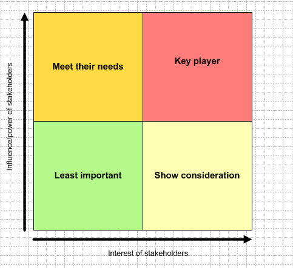

matiz

Source image:https://www.stakeholdermap.com/stakeholder-matrix.html

[figure not shown]

### 6. Muestra la solución

En esta actividad debemos realizar los diagramas de arquitectura para asegurarnos que todos estamos pensando y conceptualizando la misma solución.

Es ideal conocer las herramientas y la arquitectura para poder entender si los integrantes del equipo de desarrollo tienen los skills necesarios para poder desarrollar la solución.

Para implementar esta dinámica es necesario saber cual es el MVP (Producto mínimo viable) que se puede desarrollar para poder mostrar cual es la solución y entender si la misma es factible y si es de interés para los usuarios finales del producto.

### 7. ¿Qué te quita el sueño?

El objetivo es identificar los riesgos y poder resolverlos. Un ejemplo puede ser el siguiente:

> **Problemática**: Necesitamos trabajar en un proyecto que se desarrolle en GO, pero no hay desarrolladores que conozcan cómo programar en este lenguaje.

> **Solución**: Planificar capacitaciones para mitigar el riesgo.

Algunas problemáticas no podrán ser resueltas tan fácilmente ya que pueden ser restricciones regulatorias de alguna industria, por lo cual es necesario que las mismas sean informadas al equipo y ver que acciones tomar.

### 8. Estimar tamaños

Necesitamos poder estimar a alto nivel cuál es la duración del proyecto y el esfuerzo que puede tener.

Es difícil poder estimar fechas exactas, más aún cuando estamos en el inicio del proyecto.

Una de las dinámicas que se puede aplicar es realizar un planning poker

### 8.1. Planning poker

#### ¿Que es el planning poker?

El Planning Poker es una técnica para la estimación de tareas y fue utilizado por James Grenning en un equipo ágil utilizando XP en 2002.

#### Cartas de planning poker

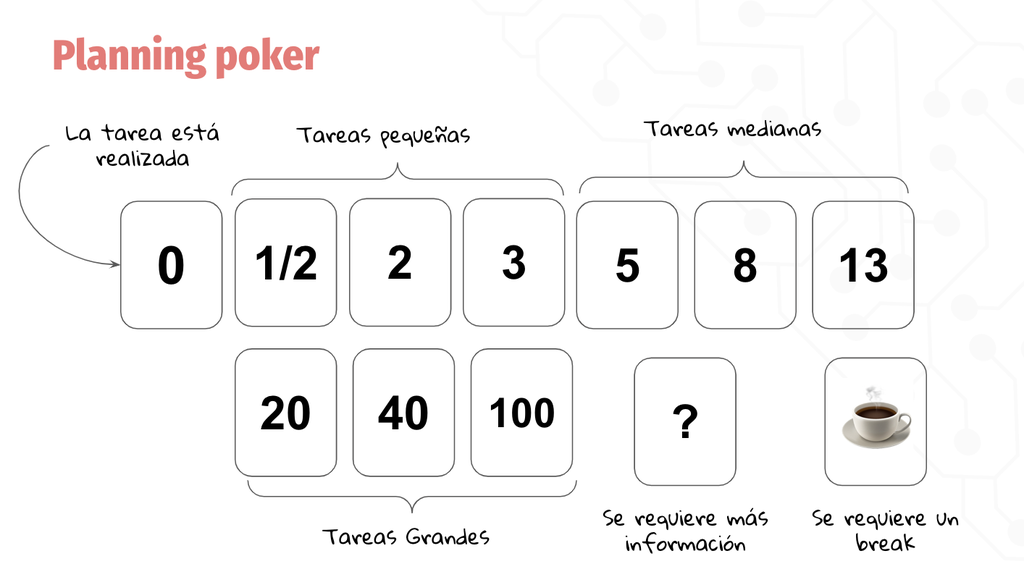

#### ¿Cómo se realiza la estimación?

Cada miembro del equipo de desarrollo selecciona una carta. Una vez que todos tengan seleccionada una carta, se ponen boca arriba todas a la vez.

Posteriormente nos quedamos con la estimación media más elegida, o se debate hasta conseguir la unanimidad.

Esto se repite con cada historia de usuario que haya que estimar.

Algunas paginas para poder realizar esta dinámica de forma online:

- [Planning poker agile App](https://planning-poker-agile.web.app/): Esta aplicación es open source y permite estimar las historias de usuarios.
- [Planning-poker](https://www.planningpoker.com/): Es una aplicación que permite también hacer partidas pero en su plan free es solo para cinco usuarios.

### 9. Restricciones

Los proyectos tienen factores clave de ejecución tales como : ⌛tiempo, 🔍 alcance, 💰costes y, por supuesto, 👏calidad. Es fundamental saber cuáles de estos factores son **inamovibles** y en cuáles hay **flexibilidad**.

Otros factores que también se pueden tener en cuenta son:

- 🔍 Facilidad de uso
- 🔍 Seguridad
- 🔍 Velocidad
- 🔍 Time to market, entre otras.

### 10. ¿Cuánto cuesta?

Aquí definimos cuál es el entregable a realizar en el roadmap y cuales son los costos asociados.

Para la estimación es necesario tener en cuenta los siguientes puntos:

- Estimar el equipo de proyecto.
- Tiempo de duración
- Presupuesto.

#### Referencias:

1. James Grenning (2002). Planning Poker or How to avoid analysis paralysis while release planning, Link: https://wingman-sw.com/papers/PlanningPoker-v1.1.pdf
2. Elleithy, S. & Sidky, A. (2014). The mindset behind estimating and planning for agile. Paper presented at PMI® Global Congress 2014 — North America, Phoenix, AZ. Newtown Square, PA: Project Management Institute, Link: https://www.pmi.org/learning/library/mindset-estimating-planning-agile-9340
3. Amit Maimon ( 2017).How Self-Managed Teams Can Resolve Conflict. Link: https://hbr.org/2017/04/how-self-managed-teams-can-resolve-conflict 4.Jonathan Rasmusson (2010). The Agile Samurai. How Agile Masters Deliver Great Software.